# LAB - HW2 - Face Mask Prediction

## Final Report

### By Shani Pais and Liam Hazan

github link: https://github.com/shanipa/Covid_Mask_Detection

# EDA

```python
import os
import numpy as np
import cv2
import json
import matplotlib.pyplot as plt
from matplotlib import patches
import torch
import torch.nn as nn
from torch.utils.data import TensorDataset, DataLoader
import transforms as T
import utils
from tqdm import tqdm
from PIL import Image, ImageOps
from engine import train_one_epoch, evaluate
import pandas as pd
from IPython import display
```

```python
def parse_images_and_bboxes(image_dir):
    """
    Parse a directory with images.
    :param image_dir: Path to directory with images.
    :return: A list with (filename, image_id, bbox, proper_mask) for every image in the image_dir.
    """
    example_filenames = sorted(os.listdir(image_dir))
    data = []
    for filename in example_filenames:
        if filename.endswith(".jpg"):
            image_id, bbox, proper_mask = filename.strip(".jpg").split("__")
            bbox = eval(bbox)
            if any(cord <= 0 for cord in bbox):
                print(f"{filename} skipped")
                continue
            proper_mask = 1 if proper_mask.lower() == "true" else 0
            data.append((filename, image_id, bbox, proper_mask))
    print("data length:", len(data))
    return data


def calc_iou(bbox_a, bbox_b):
    """.to(device)
    Calculate intersection over union (IoU) between two bounding boxes with a (x, y, w, h) format.
    :param bbox_a: Bounding box A. 4-tuple/list.
    :param bbox_b: Bounding box B. 4-tuple/list.
    :return: Intersection over union (IoU) between bbox_a and bbox_b, between 0 and 1.
    """
    x1, y1, w1, h1 = bbox_a
    x2, y2, w2, h2 = bbox_b
    w_intersection = min(x1 + w1, x2 + w2) - max(x1, x2)
    h_intersection = min(y1 + h1, y2 + h2) - max(y1, y2)
    if w_intersection <= 0.0 or h_intersection <= 0.0:  # No overlap
        return 0.0
    intersection = w_intersection * h_intersection
    union = w1 * h1 + w2 * h2 - intersection    # Union = Total Area - Intersection
    return intersection / union


def show_images_and_bboxes(data, image_dir, pad=False):
    """
    Plot images with bounding boxes. Predicts random bounding boxes and computes IoU.
    :param data: Iterable with (filename, image_id, bbox, proper_mask) structure.
    :param image_dir: Path to directory with images.
    :return: None
    """
    for filename, image_id, bbox, proper_mask in data:
        # Load image
        im = cv2.imread(os.path.join(image_dir, filename))
        # BGR to RGB
        im = im[:, :, ::-1]
        if pad:
            im = pad_image(Image.open(os.path.join(image_dir, filename)).convert("RGB"))
        # Ground truth bbox
        x1, y1, w1, h1 = bbox
        # Predicted bbox
        x2, y2, w2, h2 = random_bbox_predict(bbox)
        # Calculate IoU
        iou = calc_iou(bbox, (x2, y2, w2, h2))
        # Plot image and bboxes
        fig, ax = plt.subplots()
        ax.imshow(im)
        rect = patches.Rectangle((x1, y1), w1, h1,
                                 linewidth=2, edgecolor='g', facecolor='none', label='ground-truth')
        ax.add_patch(rect)
        rect = patches.Rectangle((x2, y2), w2, h2,
                                 linewidth=2, edgecolor='b', facecolor='none', label='predicted')
        ax.add_patch(rect)
        fig.suptitle(f"proper_mask={proper_mask}, IoU={iou:.2f}")
        ax.axis('off')
        fig.legend()
        plt.show()



def random_bbox_predict(bbox):
    """
    Randomly predicts a bounding box given a ground truth bounding box.
    For example purposes only.
    :param bbox: Iterable with numbers.
    :return: Random bounding box, relative to the input bbox.
    """
    return [x + np.random.randint(-15, 15) for x in bbox]

def pad_image(im, desired_size=224):
    old_size = im.size
    delta_w = desired_size - old_size[1]
    delta_h = desired_size - old_size[0]
    padding = (0, 0, delta_h, delta_w)
    new_im = ImageOps.expand(im, padding)

    return new_im
```

Let's first look on some photos from the train, and how the file name should look

```
003701__[0, 43, 21, 30]__False.jpg skipped
004828__[72, 85, 50, -2]__False.jpg skipped
008710__[40, 78, 0, 86]__True.jpg skipped
009266__[54, 44, 0, 0]__False.jpg skipped
009963__[0, 37, 50, 63]__True.jpg skipped
data length: 15542
```

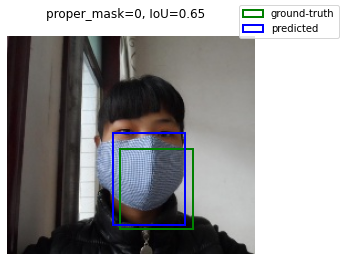

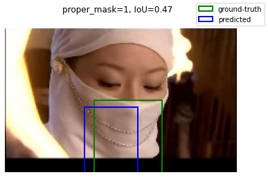

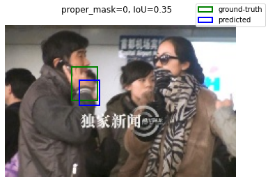

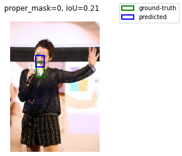

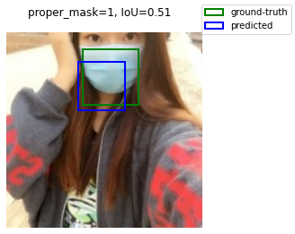

```python
dir = "train"
data = parse_images_and_bboxes(dir)
show_images_and_bboxes(data[5:10],dir)
```

We can learn very important inormation regadind the data from just looking on those images.  
In the fist image it's clearfy the intention that even though the man is wearking a mask, the ground truth is false, because it is not in one color. However, we can learn from the second image that there is some missclasifications in the ground truth as well, as it's not a proper mask.  
In addition from the thirs image we can see that the people have items that cover thier mouths, whoever there is a bounding box on only one of them, the left one, as decribed in the instructions.  
from the forth picture it seems like the bounding box better bound the item near the mouth rather than the mouth itself.  
Another very important thing we will see and need to adrress it in our preprocessing is that our pictures our of difrrent sizes. We have decided to adress it with padding the image from right and bottom, rather than keeping the pic in the center, so in that way we don't need to modify the box coordinates as well. We also prefered it from resizing so we will keep the proportions right.  
For example:

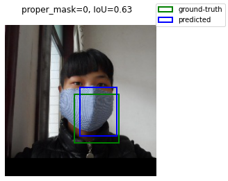

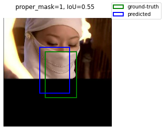

[figure not shown]

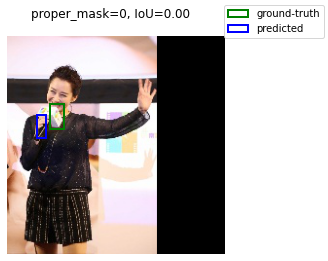

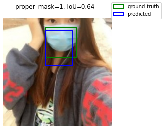

```python
show_images_and_bboxes(data[5:10],dir, True)
```

# Expirements

## Data loading, pre-processing and cleaning

For both of our models we have preformed the same process. We difined a designated dataset object, and made the following steps:

1. Defined transformation for the data. This was more of infustructure preperation to a case we will expirence with data augmentation. For our case we just transformed it to tensor
2. We called the parse_images_and_bboxes, where we added our pading as well
3. We changed the bounding box to be in format of [x_min, y_min, x_max, y_max], so it will fit the format our models are expecting. afterwords, for calcluating matrices and predictions we revert it back to the original standard
4. For some images, the bounding box was negetive, so we cleaned them out
5. Our model also preforms data normalization

## Optimizers, Hyper parameter tuning, Regularization

In all our expirements, we tried difrent *batch sizes*, *learning rates*, *using a scedualre*, until we decided to use the same optimizer, hyper parameters, and scedualre as followes:

```python
params_dict = {'Optimizer':'Adam',
               'Learning Rate':'0.001',
               'Scheduler': 'StepLR',
               'Step Size':'3',
              'Gamma':'0.1',
              'Batch size':'32'}
params = pd.DataFrame.from_dict(params_dict, orient='index', columns=['value'])
```

```python
params
```

|  | value |
| --- | --- |
| Optimizer | Adam |
| Learning Rate | 0.001 |
| Scheduler | StepLR |
| Step Size | 3 |
| Gamma | 0.1 |
| Batch size | 32 |

In addition, we also used gradient clipping, with value 1, in order to avoid exploding gradients.

## Model Architecture and Loss Functions

We used the **Faster R-CNN<\b>, model. It was first propused in the paper *Faster R-CNN: Towards Real-Time Object Detection with Region Proposal Networks* by Ren at. el, which you can find here: https://arxiv.org/pdf/1506.01497.pdf.**

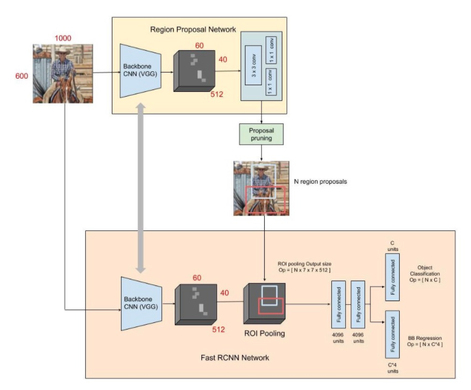

```python
display.Image("./report_images/model_arc.png")
```

Faster R-CNN was first published in 2015 and it is the most widely used state of the art version of the R-CNN family.  
Faster R-CNN is a detection pipeline that uses the RPN (Region Proposal Network ) as a region proposal algorithm, and Fast R-CNN as a detector network.  
the RPN stage starts with feeding the image to a backbone CNN (e.g. resnet50) and then for every point in the output feature map, the network has 3 CNN heads. one, to give a 512-d feature map for every location. two, to predict whether an object is present in the image at its corresponding coordinates and three, to estimate its size.  
the Fast R-CNN stage also starts with feeding the image to a backbone CNN (which shares parameters the RPN’s CNN). then, the bounding box proposals from the RPN are used to pool features from the backbone feature map with ROI pooling layer. the output of the pooling layer goes through 2 FC layers and then the output used for our 2 tasks, object detection and BB regression in 2 separated heads.  
In our Experiments we used Faster R-CNN with 2 different backbone CNNs. The first is mobilenet v3 which is known to be efficient and light for quick experimentation. The second is resnet 50 which is widely used due to its good trade-off between size and performance.  
We chose our model based on the one that achived the best score, that is a combanation of the model accuracy and IOU. (based on preformenced on the test data set)

## First Experiment - using resnet50 backbone

We trained our model for 10 epochs, where each eopch took approxiamtly 25mins, including inference on both train and test data set. we choode the model from the 9th eopch, which achived the following results: (and this is the one we used for the competition)

```python
cols = ['Accuracy', 'IOU', 'Total Score']
data = {'Train':[0.828, 0.72, 0.774],
       'Test':[0.791, 0.656, 0.723]}
first_exp = pd.DataFrame.from_dict(data, orient='index', columns=cols)
```

```python
first_exp
```

|  | Accuracy | IOU | Total Score |
| --- | --- | --- | --- |
| Train | 0.828 | 0.720 | 0.774 |
| Test | 0.791 | 0.656 | 0.723 |

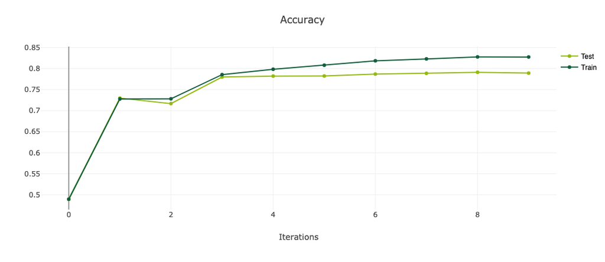

```python
display.Image("./report_images/acc_1.png")
```

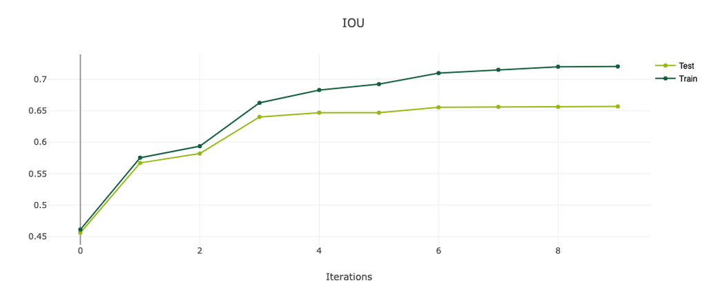

```python
display.Image("./report_images/iou_1.png")
```

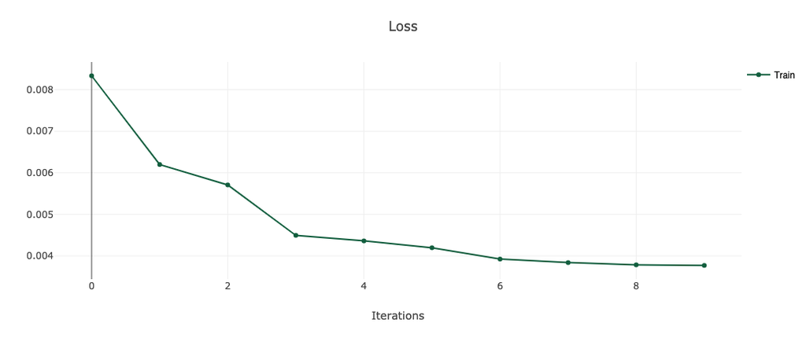

```python
display.Image("./report_images/loss_1.png")
```

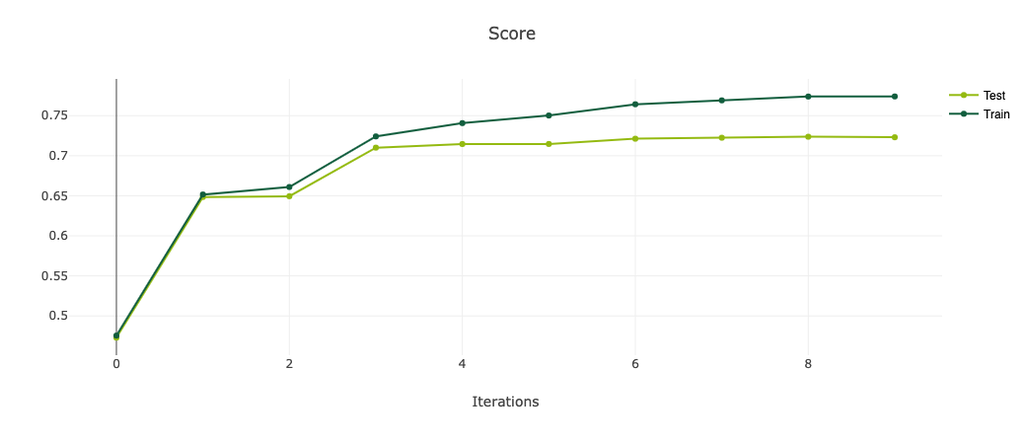

```python
display.Image("./report_images/score_1.png")
```

We can see that at first the results on both train and test imporoved rapidly, but afterwords there was a slowdown in both, while creating a gap infavor of the train data (as expected).

```python
data_2 = {'Train':[0.657, 0.553, 0.605],
       'Test':[0.652, 0.537, 0.595]}
second_exp = pd.DataFrame.from_dict(data_2, orient='index', columns=cols)
second_exp
```

|  | Accuracy | IOU | Total Score |
| --- | --- | --- | --- |
| Train | 0.657 | 0.553 | 0.605 |
| Test | 0.652 | 0.537 | 0.595 |

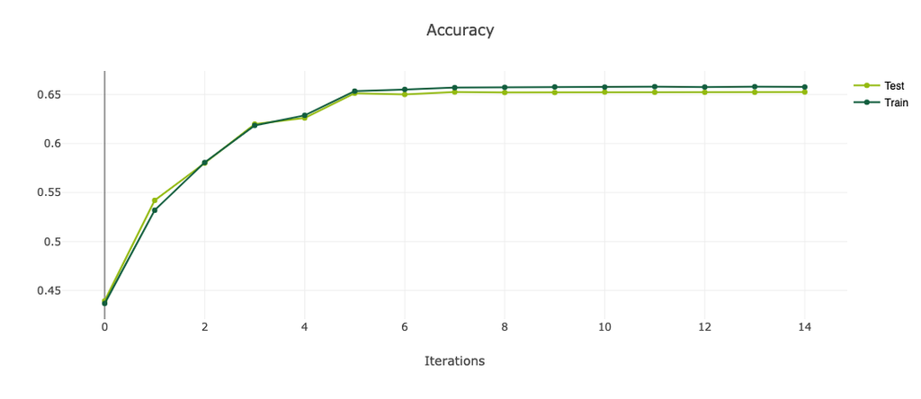

```python
display.Image("./report_images/acc_2.png")
```

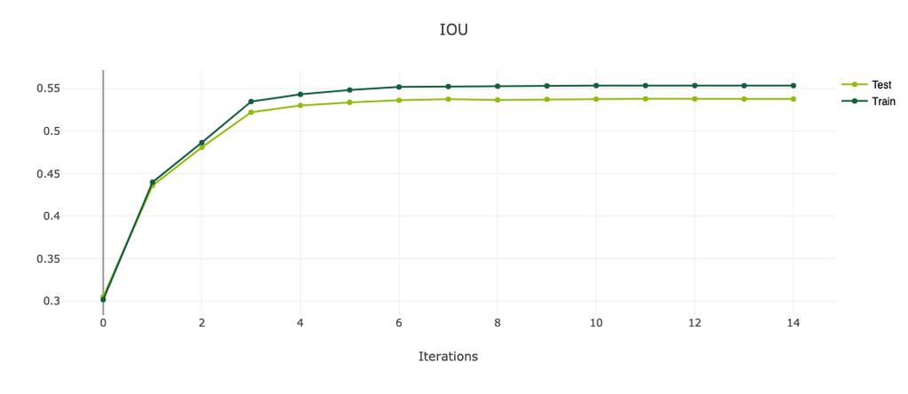

```python
display.Image("./report_images/iou_2.png")
```

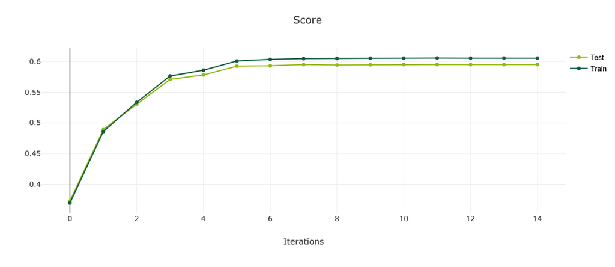

```python
display.Image("./report_images/score_2.png")
```

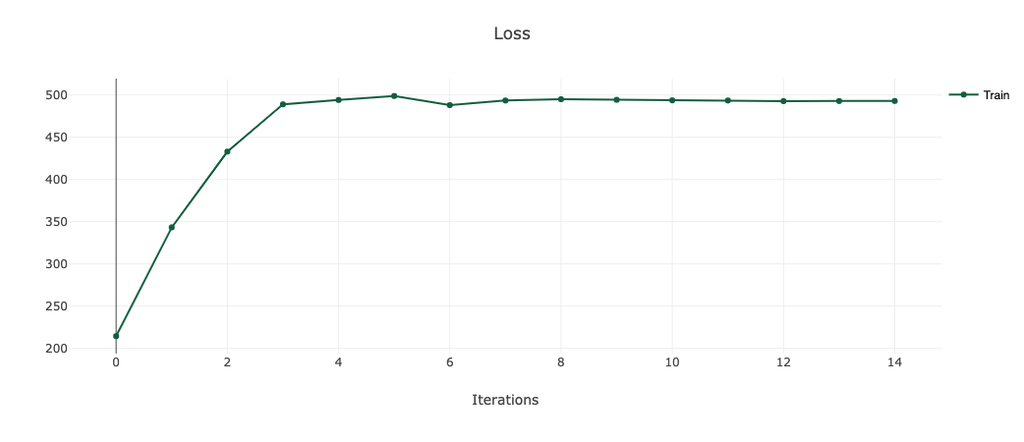

```python
display.Image("./report_images/loss_2.png")
```

- There was some scaling issue for the Loss reporting

# Conclusion

From our expirement we can see a clear trade-off between the model's complexity (or more accuratly it's simplicity) to it's result.  
While we were able to quickly train and predict using the mobile backbone, the resnet model achived much better results.  
In addition, we focused most of our effort on the first model, and maybe there is stuff that need to be consider more when using a lighter model - like diffrent learning rate, or improving the generalization using data augumentaion.  
We also learned that object detection is a super cool filed, and not as scary as you get into it (after very good hours).